# Bruhn_A04_2

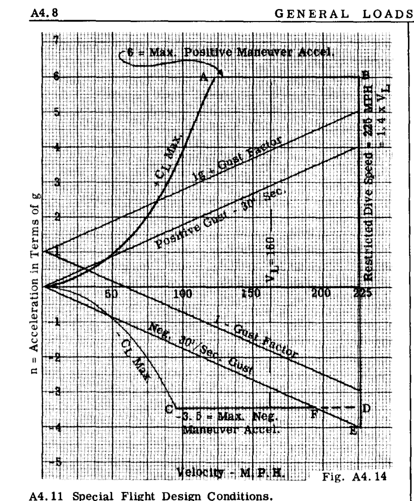

図A4.14

## A4.11 特別飛行設計条件

主翼または胴体構造の特定の部分に対して臨界（クリティカル）となる可能性のある飛行条件は、他にも数多く存在する。ほとんどの飛行機は着陸速度を低下させるためにフラップを装備しており、これらのフラップは最小着陸速度の少なくとも2倍の速度で下げられる。フラップを下げた翼型は、翼型特性の大きさと位置について異なる値を持つため、フラップが操作され得る最大速度に関する規定の要件内で、考えられるすべてのフラップ条件について主翼構造をチェックする必要がある。一般的に言えば、フラップ条件はフラップより内側の主翼部分にのみ影響を及ぼし、通常は後方梁のウェブまたは剪断壁、およびねじり箱（トルクボックス）の天面および底面壁に対してのみ臨界となる。これは、偏向フラップによって圧力中心が大幅に後方に移動し、その結果、後方剪断壁に多くの剪断荷重が発生するとともに、従来の片持ち箱型金属梁にねじりモーメントが発生するためである。

飛行機は同様に、補助翼（エルロン）条件についても調査されなければならない。補助翼の作動は、飛行機の主翼の左右で異なる空気荷重を生み出し、これにより飛行機の角ロール加速度が発生する。さらに、偏向した補助翼は翼型特性の大きさと位置を変化させるため、補助翼条件における荷重が通常の飛行条件における荷重よりも臨界的であるかどうかを判断するための計算を実行しなければならない。

尾翼への突風によるピッチングモーメントに起因する角加速度については、エンジンが主翼に取り付けられ、前縁より前方に配置されている場合、主翼への荷重をチェックする必要がある。

降着装置が主翼に取り付けられている場合、または燃料やエンジンが主翼内および主翼上に搭載されている場合、着陸状態で主翼構造に生じる荷重は、降着装置およびエンジン取付点より内側の主翼構造の一部に対して臨界となる場合がある。

## A4.12 剛性飛行機の加速度運動を伴う例題

前述のように、加えられた荷重系に慣性力を加えることにより、加速度運動状態にある飛行機を静的平衡状態に置くことが一般的な実務である。通常、飛行機は剛体であると仮定される。この一般的な手順を説明するために、いくつかの例題を提示する。

### 例題1

図 A4.15 は、海軍の航空母艦に着陸し、飛行機の着艦フックにかかるケーブルの引張力 $T$ によって制動されている飛行機を示している。飛行機の重量が 12,000 lbs. であり、飛行機に $3.5g$ ( $112.7\text{ ft/sec}^2$ ) の一定の加速度が与えられる場合、フックの引張力 $T$ 、車輪の反力 $R$ 、およびフックの作用線と飛行機の重心（c.g.）との間の距離（ $d$ ）を求めよ。着陸速度が 60 M.P.H. である場合、停止距離はいくらか。

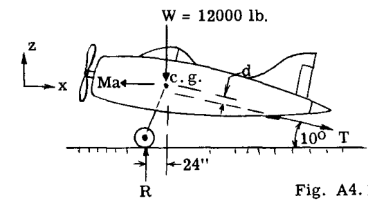

図A4.15

**解法：**

飛行機が制動ケーブルに接触すると、飛行機は図 A4.15 に対して右方向へ減速される。運動は水平方向の純粋な並進運動である。慣性力は、

$$Ma = \frac{W}{g}a = \left(\frac{12000}{g}\right) 3.5g = 42000\text{ lb.}$$

慣性力は加速度の方向と反対に作用するため、図 A4.15 に示すように左向きとなる。

未知の力 $T$ と $R$ は、静的平衡方程式を使用することで解くことができる。

$$\Sigma F_x = -42000 + T \cos 10^\circ = 0$$

したがって、

$$T = 42700\text{ lb.}$$

また、

$$\Sigma F_z = -12000 + R - 42700 \times \sin 10^\circ = 0$$

したがって、

$$R = 19420\text{ lb.}$$

距離（ $d$ ）を求めるために、飛行機の重心（c.g.）のまわりのモーメントを計算する。

$$\Sigma M_{\text{c.g.}} = 19420 \times 24 - 42700 d = 0$$

したがって、

$$d = 10.9\text{ in.}$$

着陸速度 $V_0 = 60\text{ M.P.H.} = 88\text{ ft/sec.}$

$$V^2 - V_0^2 = 2as$$

値を代入すると、

$$0^2 - 88^2 = 2(-112.7) s$$

したがって、停止距離 $s = 34.4\text{ ft.}$

### 例題2

[figure not shown]

**解法：**

力は、台車の速度が小さく、したがって飛行機の主翼への揚力および飛行機の抗力が無視できる、カタパルト走行の開始直後について決定される。

飛行機の尾部に向かって作用する水平慣性力は、

$$Ma = \left(\frac{9000}{g}\right) 3.0g = 27000\text{ lb.}$$

静力学より、

$$\Sigma F_x = -900 - P + 27000 = 0$$

したがって、

$$P = 26100\text{ lb.}$$

$R_2$ を求めるために、点 A のまわりのモーメントを計算する。

$$\Sigma M_A = 9000 \times 55 + 27000 \times 78 - 900 \times 83 - 85R_2 = 0$$

したがって、

$$R_2 = 29800\text{ lb. (上向き)}$$

$$\Sigma F_z = 29800 - 9000 + R_1 = 0$$

したがって、

$$R_1 = -20800\text{ lb. (下向きに作用)}$$

カタパルト軌道の端における速度は、次の方程式から求めることができる。

$$V^2 - V_0^2 = 2as$$

$$V^2 - 0 = 2 \times 96.6 \times 35$$

または、

$$V = 82\text{ ft/sec.} = 56\text{ M.P.H.}$$

### 例題3

図 A4.17 に示す輸送機が着陸時に接地したばかりであり、飛行機を静止させるために後輪に 35000 lb. の制動力が加えられていると仮定する。着陸時の水平速度は 85 M.P.H. ( $125\text{ ft/sec}$ ) である。飛行機への空気力を無視し、プロペラ力はゼロであると仮定して、地面反力 $R_1$ および $R_2$ はいくらか。また、一定の制動力による着陸滑走距離はいくらか。

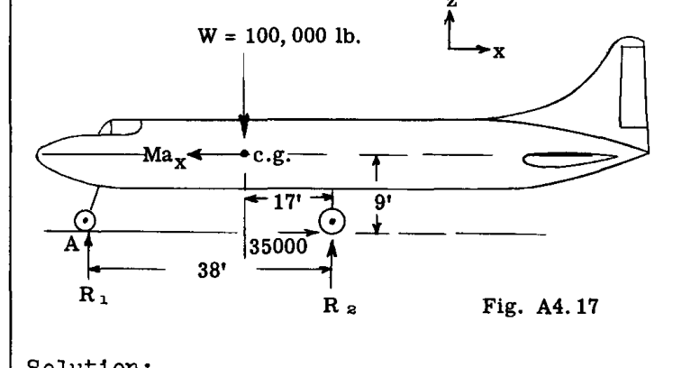

図A4.17

**解法：**

飛行機は水平方向に減速されているため、飛行機の重心（c.g.）を通る慣性力は飛行機の前方に向かって作用する。制動力が与えられているため、平衡方程式から減速係数を解くことができる。

$$\Sigma F_x = 35000 - Ma_x = 0$$

したがって、

$$Ma_x = 35000$$

または、

$$\left(\frac{W}{g}\right) a_x = 35000$$

これより、

$$a_x = \left(\frac{35000}{100000}\right) 32.2 = 11.27\text{ ft/sec}^2$$

着陸滑走距離（ $s$ ）を求めるために、

$$V^2 - V_0^2 = 2 a_x s$$

$$0 - 125^2 = 2 (-11.27) s$$

したがって、

$$s = 695\text{ ft.}$$

点（A）のまわりのモーメントをとって $R_2$ を求める。

$$\Sigma M_A = 100,000 \times 21 - 35000 \times 9 + 38 R_2 = 0$$

$$R_2 = 47000\text{ lb. (2輪分)}$$

$$\Sigma F_z = 47000 - 100,000 + R_1 = 0$$

$$R_1 = 53000\text{ lb.}$$

### 例題4

図 A4.18 の飛行機は重量が 14,000 lb. である。これが 500 M.P.H. ( $733\text{ ft/sec}$ ) の速度で水平飛行しているとき、パイロットが操縦桿を引いて曲率半径 2500 ft. の湾曲した経路へと引き起こす。エンジンの推力と飛行機の抗力は、互いに等しく、反対方向で、同一直線上にあると仮定する（図 A4.18 には図示せず）。

以下を求めよ： - (a) $Z$ 方向における飛行機の加速度 - (b) 主翼揚力（ $L$ ）および尾翼（ $T$ ）荷重 - (c) 飛行機荷重係数（ロードファクター）

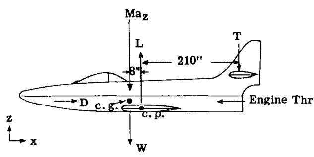

図A4.18

**解法：**

$$\text{加速度 } a_z = \frac{V^2}{r} = \frac{733^2}{2500} = 215\text{ ft/sec}^2$$

または $214.5 / 32.2 = 6.68g$ （上向き）。

飛行経路に垂直で、下向きに作用する慣性力は以下に等しい：

$$Ma_z = \left(\frac{14000}{g}\right) 6.68g = 93520\text{ lb.}$$

この力を重心（c.g.）を通して飛行機に配置することで静的平衡が促されるため、尾翼荷重 $T$ を求めるために、主翼の空力中心（c.p.）のまわりのモーメントを計算する。

$$\Sigma M_{\text{c.p.}} = -(14000 + 93520) 8 + 210 T = 0$$

したがって、

$$T = 4100\text{ lb. (下向き)}$$

主翼揚力（ $L$ ）を求めるために、以下を使用する：

$$\Sigma F_z = -4100 - 14000 - 93520 + L = 0$$

$$L = 111600\text{ lb.}$$

$$\text{飛行機荷重係数} = \frac{\text{飛行機揚力}}{W} = \frac{111600 - 4100}{14000} = 7.7$$

### 例題5

例題4で使用した飛行機が、その例題で使用したのと同じ姿勢にあると仮定する。ここで、飛行機はパイロットによってさらに操縦され、操縦桿を突然前方に押し出すことで、飛行機に $4\text{ rad/sec}^2$ のピッチング加速度を与える。

- 1. 主翼への揚力は変化しないと仮定して、慣性力および尾翼荷重 $T$ を求めよ。
- 2. 重量が 1500 lb. であり、その重心（c.g.）位置が図 A4.19 に示されているジェットエンジンにかかる力を求めよ。

飛行機の慣性モーメント $I_y$ （ピッチング）は $300,000\text{ lb. sec}^2\text{ in.}$ に等しいと仮定する。

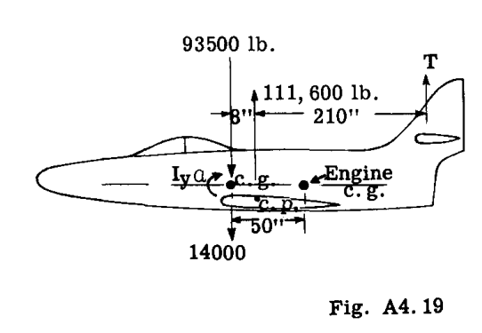

図A4.19

**解法：**

図 A4.19 は、問題4で求められた揚力および慣性力を有する飛行機の自由体を示している。

角加速度 $\alpha = 4\text{ rad/sec}^2$ による追加の慣性力は、以下に等しい：

$$I_y \alpha = 300000 \times 4 = 1,200,000\text{ in. lb.}$$

これは時計回り、すなわち角加速度の方向と反対に作用する。

飛行機は現在、静的平衡状態にあり、尾翼荷重 $T$ を求めるために、飛行機の重心（c.g.）のまわりのモーメントを計算する。

$$\Sigma M_{\text{c.g.}} = 1,200,000 - 111600 \times 8 - 218 T = 0$$

$$T = 1409\text{ lb.}$$

$Ma_z$ を求めるために、以下を行う：

$$\Sigma F_z = 111600 - 14000 + 1409 - Ma_z = 0$$

$$Ma_z = 99009\text{ lb.}$$

したがって、

$$a_z = \left(\frac{99009}{14000}\right) g = 7.1g\text{ ft/sec}^2$$

エンジンの重心（c.g.）は、図 A4.19 に示すように、飛行機の重心（c.g.）から 50 インチ後方にある。エンジンにかかる力は、エンジン自体の重量 1500 lb. と、 $a_z$ および $\alpha$ による慣性力となる。

$a_z$ による慣性力は、以下に等しい：

$$Ma_z = \left(\frac{1500}{g}\right) 7.1g = 10630\text{ lb.}$$

角加速度 $\alpha$ による慣性力は、以下に等しい：

$$M r \alpha = \frac{1500}{32.2 \times 12} \times 50 \times 4 = 776\text{ lb. (下向き)}$$

したがって、エンジンにかかる合力は以下に等しくなる：

$$1500 + 10630 + 776 = 12906\text{ lb. (下向き)}$$

注意：もしエンジンが飛行機の重心（c.g.）の前方にあった場合、776 lb. の慣性力は下向きではなく上向きに作用することになる。

特定の飛行機部品における角加速度による慣性力を計算する際、方程式 $F = M r \alpha$ は、その特定の部品がそれ自体の重心重心 Y 軸まわりの質量慣性モーメントを無視できる程度に小さいと仮定している。大型の部品の場合、この重心重心質量慣性モーメントが無視できないほど大きくなる可能性があり、飛行機の $I_y$ に含める必要がある。

その場合、そのような部品の慣性力を求めるためには、方程式 $F = M r \alpha$ を以下のように修正する必要がある：

$$F = \frac{(I_{\text{c.g.}} \alpha)}{r}$$

ここで、 - $r$ = 飛行機の重心（c.g.）から部品の重心（c.g.）までの距離またはアーム。 - $I_{\text{c.g.}}$ = 飛行機の重心（c.g.）まわりの部品の質量慣性モーメント。 $I_0 + M r^2$ に等しい。 - ここで $I_0$ は、部品自体の重心重心 Y 軸まわりの質量慣性モーメントである。 - $F$ = 半径 $r$ に垂直な lb. 単位の慣性力。

### 例題6

図 A4.20 は、総重量が 100,000 lb. である大型輸送機を示している。飛行機のピッチング質量慣性モーメントは $I_y = 40,000,000\text{ lb. sec}^2\text{ in.}$ である。

飛行機は、前輪が地面からわずかに浮いた状態で水平着陸を行っている。後輪への反力は 319,000 lb. であり、これは 100,000 lb. の抗力成分と 300,000 lb. の垂直成分を与えるような角度で傾いている。

以下を求めよ： - (a) 飛行機にかかる慣性力 - (b) 重量が 180 lb. であり、その位置が図 A4.20 に示されているパイロットにかかる合力荷重

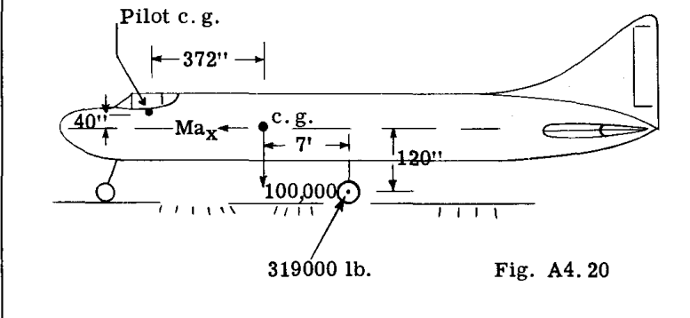

図A4.20

**解法：**

この例題では主翼の揚力は無視される。

飛行機にかかる慣性力は、力 $Ma_x$ および $Ma_z$ と、偶力 $I_{\text{c.g.}} \alpha$ である。

$Ma_x$ を求めるために、以下を行う：

$$\Sigma F_x = 100,000 - Ma_x = 0$$

または、

$$Ma_x = 100,000\text{ lb.}$$

したがって、

$$a_x = \frac{100,000}{M} = \left(\frac{100,000}{100,000}\right) g = 1g \rightarrow$$

$Ma_z$ を求めるために、以下を行う：

$$\Sigma F_z = 300,000 - 100,000 - Ma_z = 0$$

$$Ma_z = 200,000\text{ lb.}$$

したがって、

$$a_z = \frac{200,000}{M} = \left(\frac{200,000}{100,000}\right) g = 2g \uparrow$$

慣性偶力 $I_{\text{c.g.}} \alpha$ を求めるために、飛行機の重心（c.g.）のまわりのモーメントを計算する。

$$\Sigma M_{\text{c.g.}} = -100,000 \times 120 - 300,000 \times 84 + I_{\text{c.g.}} \alpha = 0$$

$$I_{\text{c.g.}} \alpha = 37,200,000\text{ lb. in.}$$

したがって、角加速度 $\alpha$ は、

$$\alpha = \frac{37,200,000}{40,000,000} = 0.93\text{ rad/sec}^2$$

#### パイロットにかかる合力荷重の計算：

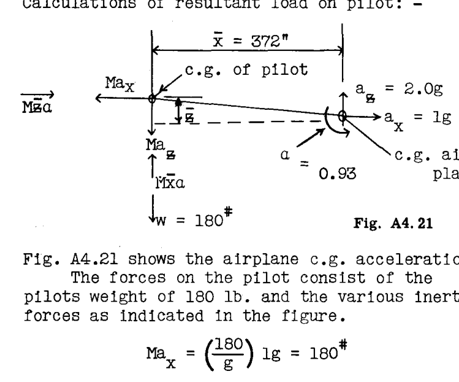

図A4.21

図 A4.21 は飛行機の重心（c.g.）の加速度を示している。パイロットにかかる力は、パイロットの重量 180 lb. と、図に示すさまざまな慣性力から構成される。

$$Ma_x = \left(\frac{180}{g}\right) 1g = 180\text{ lb.}$$

$$Ma_z = \left(\frac{180}{g}\right) 2.0g = 360\text{ lb.}$$

角加速度 $\alpha$ による慣性力は、飛行機の重心（c.g.）とパイロットを結ぶ半径アームに垂直に作用する。便宜上、この垂直力はその $z$ および $x$ 成分に置き換えられる。

$$F_x = M \bar{z} \alpha = \frac{180}{32.2 \times 12} \times 40 \times 0.93 = 17\text{ lb.}$$

$$F_z = M \bar{x} \alpha = \frac{180}{32.2 \times 12} \times 372 \times 0.93 = 161\text{ lb.}$$

パイロットにかかる $x$ 方向の全速度は以下に等しい：

$$180 - 17 = 163\text{ lb.}$$

$z$ 方向の全力は：

$$360 + 180 - 161 = 379\text{ lb.}$$

## A4.13 飛行機が剛体でないことの影響

節 A4.12 の例題は、飛行機が剛体（構造的変形を受けない）であることを前提としている。この仮定に基づき、飛行状態または着陸状態において飛行機に加えられる荷重は、飛行機の加速度によって生じる慣性力と平衡状態に置かれる。特に、飛行状態と着陸状態の両方においてかなり大きな曲げ変形を受ける片持ち梁の主翼において、飛行機構造が他の構造と同様に剛体ではないことは明らかである。図 A4.21 は、ボーイング B-47 飛行機の試験用主翼を撮影した複合写真を示している。図示されている最大の上向きおよび下向きの変形は設計荷重に対するものであり、これらは一般に加えられる荷重の 1.5 倍である。これら2つの高迎角状態における加えられた荷重下での主翼の変形が、写真に示されている変形の 2/3 になると言うのは正しくない。なぜなら、設計荷重の下では、主翼のかなりの部分が材料の弾性限度を超えて、あるいは剛性率がかなり小さくなる塑性範囲まで応力を受けるためである。弾性限界は弾性係数よりも大幅に低いため、加えられた荷重の下での変形は、写真に示されているものの 2/3 よりもやや小さくなる。したがって、この写真は、主翼構造が剛体からはほど遠いものであることを非常に顕著に示している。

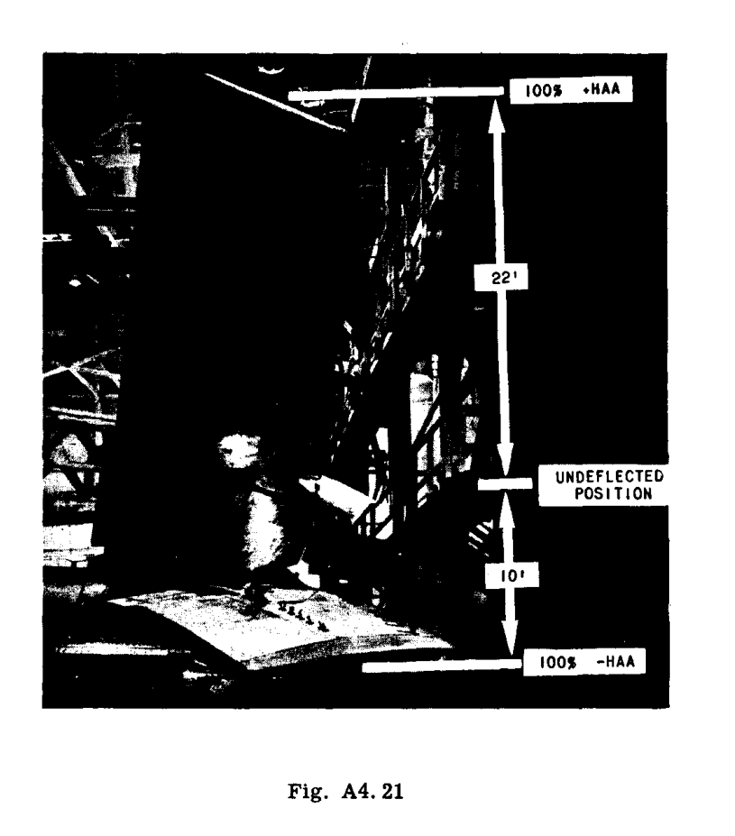

図A4.21写真

静的荷重とは、徐々に加えられ、構造に顕著な衝撃や振動を引き起こさない荷重のことである。高速航空機では、突風、飛行操縦、着陸反力は極めて急速に加えられるため、動的荷重として分類することができる。したがって、これらの動的荷重が柔軟な（非剛性の）飛行機の片持ち翼に加わると、かなり大きな主翼の変形が生じ、主翼は振動する傾向がある。したがって、この振動は主翼の質量単位の追加の加速度を引き起こし、これは主翼への追加の慣性力を意味する。さらに、外力の加わる時間的割合が主翼の固有曲げ振動数に近づくと、励起された振動によって大きな追加の主翼応力が発生する可能性がある。

第二次世界大戦までは、構造設計の目的で、実質的にすべての飛行機が剛体として仮定されていた。戦争中、剛体解析に基づく従来の設計手順で満足できる、または安全な応力を示していた荷重条件下で、航空機の破損が発生した。破損は、飛行機が剛体ではないために生じた動的過応力によるものであることは間違いなかった。

さらに、飛行機設計の進歩により、主翼が薄くなり、翼幅が比較的大きくなり、多くの場合、これらの主翼には動力装置、爆弾、翼端燃料タンクなどの集中質量が搭載されている。このように、主翼の柔軟性が増したことで、固有曲げ振動数が低下した。この事実と、飛行機の速度が大幅に向上し、それによって突風荷重がより急速に加えられるようになったこと、あるいは荷重がその特性においてより動的になりつつあるという事実とが相まって、主翼構造への全体的な荷重影響は無視できないほど大きくなり、主翼の強度設計において無視することはできない。

### 主翼荷重における空気力の一般的な動的影響

飛行機への臨界空気荷重は、パイロットによる飛行機の操縦、または横方向の突風に遭遇することによって生じる。輸送機は、乗客を輸送するという任務上、高い飛行機加速度を生み出すような急激な操縦のために設計される必要はないため、操縦荷重を加える時間は、高速から急激に引き起こす戦闘機タイプよりもかなり長くなる。

図 A4.22 は、180 M.P.H. におけるダグラス D.C.3 飛行機の引き起こし操縦の結果を、荷重係数対荷重適用時間として示している。示されているように、3.25 のピーク荷重係数は 1 秒の時間の終わりに得られた。

[figure not shown]

図A4.22

### 突風の動的影響

突風速度が高く、飛行機速度が高いほど、突風に遭遇したときに主翼に荷重を加える時間は短くなる。

NACA Technical Note 2424 は、双発のマーチン輸送機における飛行試験結果を報告している。主翼構造のさまざまな点にひずみゲージが配置され、通常の飛行機加速度も記録されたさまざまな突風条件についてひずみが読み取られた。次に、同様の飛行機の通常加速度を与えるために、緩やかな引き起こし操縦が実行された。主翼は 3.8 cps の固有振動数を持ち、飛行機速度は 250 M.P.H. であった。この報告書に記載されている結論のうちは次の通りである。 - (1) 突風の下での単位通常加速度あたりの曲げひずみは、試験のすべての測定位置および飛行条件において、緩やかな引き起こしのものよりも約 20% 高かった。(2) 主翼曲げひずみの動的成分は、主に基本主翼曲げモードの励起によるものであると考えられた。

したがって、これらの結果は、突風は、商業輸送タイプの飛行機に対して同じ飛行機通常加速度を与える操縦荷重よりも急速に主翼に空気荷重を加えるため、主翼への動的ひずみの影響は突風条件に対してより顕著であることを示している。

図 A4.23、24、および 25 は、Bisplinghoff* によって決定された、大型主翼における突風の動的影響の結果を示している。これらの図の結果は、動的影響が主翼の一部の部分で主翼力をかなり増加させ、他の部分でそれを減少させる傾向があることを示している。

[figure not shown]

図A4.23 & 図A4.24

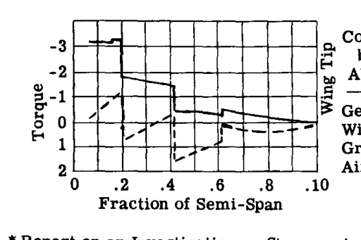

図A4.25

従来の降着装置を介して、または飛行艇への水圧によって加えられる着陸荷重も、動的荷重として分類されるのに十分なほど急速に加えられ、大翼幅の主翼に加えられるそのような荷重は、そのような構造の安全な設計において無視できない動的応力を生み出すことが判明している。

## A4.14 飛行機の構造設計における動的荷重の影響に関する一般的結論

ターボジェットおよびロケットタイプのエンジンの出現は、ほんの数年前にはほとんど夢にも思わなかったような飛行機の空気速度の可能性を切り開き、すでにトランスソニック（亜音速）およびスーパーソニック（超音速）の速度の飛行機が一般的な開発となっている。空力的な観点から、このような速度は薄い翼型を必要とし、したがって高密度の主翼を促進している。このように、ミリタリー爆撃機や近い将来のジェット民間輸送機のように、かなりの翼幅を持ち、通常はエンジン、燃料タンクなどの大きな集中質量を主翼に搭載している飛行機にとって、飛行機を剛体と仮定することは、動的応力が無視できないほど大きいため、十分に正確ではない。

主翼への動的荷重の計算は、主翼構造の質量および剛性分布が既知であることを必要とする。主翼の構造設計が開始されるとき、これらの要因は不明であるため、設計における一般的な手順は、まず主翼が剛体であるという仮定に、過去の設計経験または利用可能な研究情報に基づく補正係数を加えて設計を行い、飛行機の空力特性に対する弾性主翼の影響および動的慣性力の蓄積をほぼ処理することである。このようにして最初にこの手順によって設計された主翼は、その後、完全な動的解析によってチェックされ、結果の指示に従って修正され、その後、修正された弾性主翼に対して再計算され得る。この手順は、高速コンピューターの利用可能性により、現在では実用的となっている。

## A4.15 問題

(1). 図 A4.26 の飛行機は、ケーブルの引張力 $T$ によって航空母艦の甲板から射出され、これにより飛行機に $3.25g$ の前方加速度が与えられる。飛行機の総重量は 15,000 lb. である。 - (a) 射出ケーブルの引張荷重 $T$ 、および車輪反力 $R_1$ と $R_2$ を求めよ。 - (b) 飛行速度が 75 M.P.H. である場合、必要な射出距離および射出時間 $t$ はいくらか。

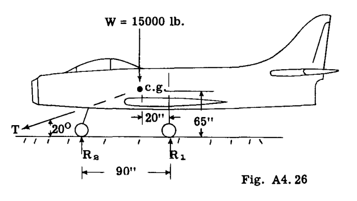

図A4.26

(2). 図 A4.26 の飛行機が滑走路に 75 M.P.H. で着陸し、後輪に垂直後輪反力の 0.4 に等しいブレーキがかけられると仮定する。飛行機の水平減速度および停止距離はいくらか。

(3). 図 A4.27 の飛行艇は、図に示すように 250,000 lb. の合力底部水圧を伴って着水する。図に示すような揚力および尾翼荷重を仮定する。飛行機のピッチング慣性モーメントは $10 \times 10^6\text{ lb. sec}^2\text{ in.}$ である。飛行機のピッチング角加速度を決定せよ。重量が 200 lb. であり、艇体の後端にある座席に位置している乗組員にかかる全荷重はいくらか。

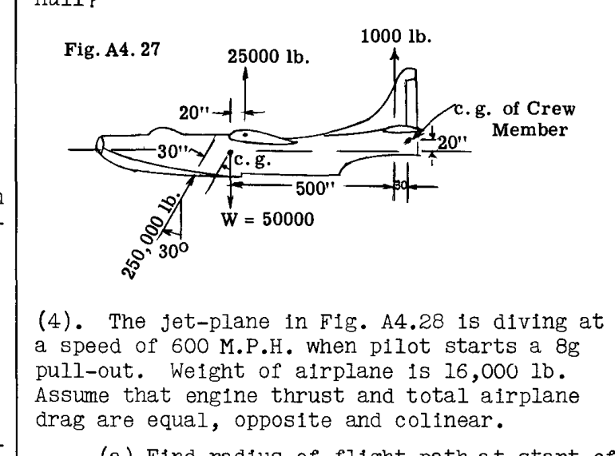

図A4.27

(4). 図 A4.28 のジェット機は、パイロットが $8g$ の引き起こしを開始したとき、600 M.P.H. の速度で急降下している。飛行機の重量は 16,000 lb. である。エンジンの推力と飛行機の全抗力は等しく、反対方向で、同一直線上にあると仮定する。 - (a) 引き起こし開始時における飛行経路の半径を求めよ。 - (b) $Z$ 方向における慣性力を求めよ。 - (c) 揚力 $L$ および尾翼荷重 $T$ を求めよ。

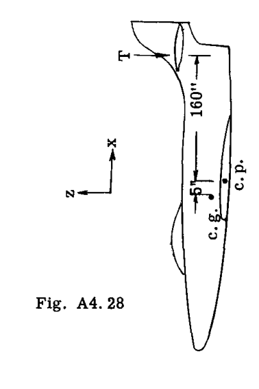

図A4.28